# (PSL) Classification Tree

## Spam Data

```r
spam = read.table("https://liangfgithub.github.io/Data/spam.txt")

spam.name=read.table("https://liangfgithub.github.io/Data/spam_name.txt")
for(i in 1:(ncol(spam)-1)) names(spam)[i]=as.character(spam.name[i,]);

names(spam)[ncol(spam)]="Y"
spam$Y = as.factor(spam$Y)
```

```r
n=dim(spam)[1];
test.id = sample(1:n, round(n*0.2))
```

## Fit a Classification Tree

In our code for analyzing the spam data, I utilized the `tree` package, which differs from the `rpart` package we employed for [[regression trees](https://liangfgithub.github.io/Rcode_W4_RegressionTree.html)]. It’s worth noting that `rpart` can also be utilized for classification tasks. I encourage you to explore the `rpart` package yourself.

```r
library(tree)
```

First, we fit a large classification tree on the Spam Data. You can use the `summary` function to obtain some summary information about the tree and understand the outputs it returns.

```r
library(tree)
spam.tr=tree(Y~., spam[-test.id,], mindev=0.005, minsize=2); # Grow a BIG tree
summary(spam.tr)
```

```
##
## Classification tree:
## tree(formula = Y ~ ., data = spam[-test.id, ], mindev = 0.005,
##     minsize = 2)
## Variables actually used in tree construction:
##  [1] "Cdollar"    "Wremove"    "Cexclam"    "Whp"        "CAPlongest"
##  [6] "Wfree"      "Wour"       "W1999"      "Wedu"       "W650"
## [11] "CAPave"     "Wbusiness"  "W85"        "Wpm"        "Wgeorge"
## [16] "Wmeeting"   "Wemail"
## Number of terminal nodes:  24
## Residual mean deviance:  0.3669 = 1342 / 3657
## Misclassification error rate: 0.06031 = 222 / 3681
```

```r
#spam.tr
```

For example, let’s delve into how the ‘df’ and ‘deviance’ are computed.

```r
myout=spam.tr$frame
leaf.nodes = myout[myout$var == "<leaf>",]
head(leaf.nodes)
dim(leaf.nodes)
```

[output not shown]

To illustrate, the sum of the ‘n’ column should be equal to the size of the training dataset.

```r
c(sum(leaf.nodes$n), nrow(spam) - length(test.id))
```

[output not shown]

The number of leaf nodes is the same as the number of parameters. Therefore, the degrees of freedom (‘df’) are equal to the size of the training samples minus the number of leaf nodes.

```r
c(sum(leaf.nodes$n) - summary(spam.tr)$size, summary(spam.tr)$df)
```

[output not shown]

Next, let’s explore how the ‘deviance’ is computed. `mydev`, computed below, should agree with the output from `summary(spam.tr)`

```r
myp = leaf.nodes[,6];
id = apply(myp, 1, min) > 0;
mydev = 2*sum(leaf.nodes$n[id]*(myp[id,1]*log(1/myp[id,1])+myp[id,2]*log(1/myp[id,2])))
c(mydev, summary(spam.tr)$dev)
```

[output not shown]

## Optimal Tree Size via CV

Cross-validation based on deviance.

```r
cv.spam1=cv.tree(spam.tr)
names(cv.spam1)
cv.spam1
plot(cv.spam1$size ,cv.spam1$dev ,type="b")
cv.spam1$size[which.min(cv.spam1$dev)]
```

[output not shown]

Cross-validation based on misclassification rate.

```r
cv.spam2=cv.tree(spam.tr, FUN = prune.misclass)
par(mfrow=c(1,2))
plot(cv.spam2$size ,cv.spam2$dev ,type="b")
plot(cv.spam2$k ,cv.spam2$dev ,type="b")

cv.spam2$size[which.min(cv.spam2$dev)]
```

[output not shown]

## Pruning

Cut the tree to the desired size using two different criteria: misclass and deviance. The results may be slightly different.

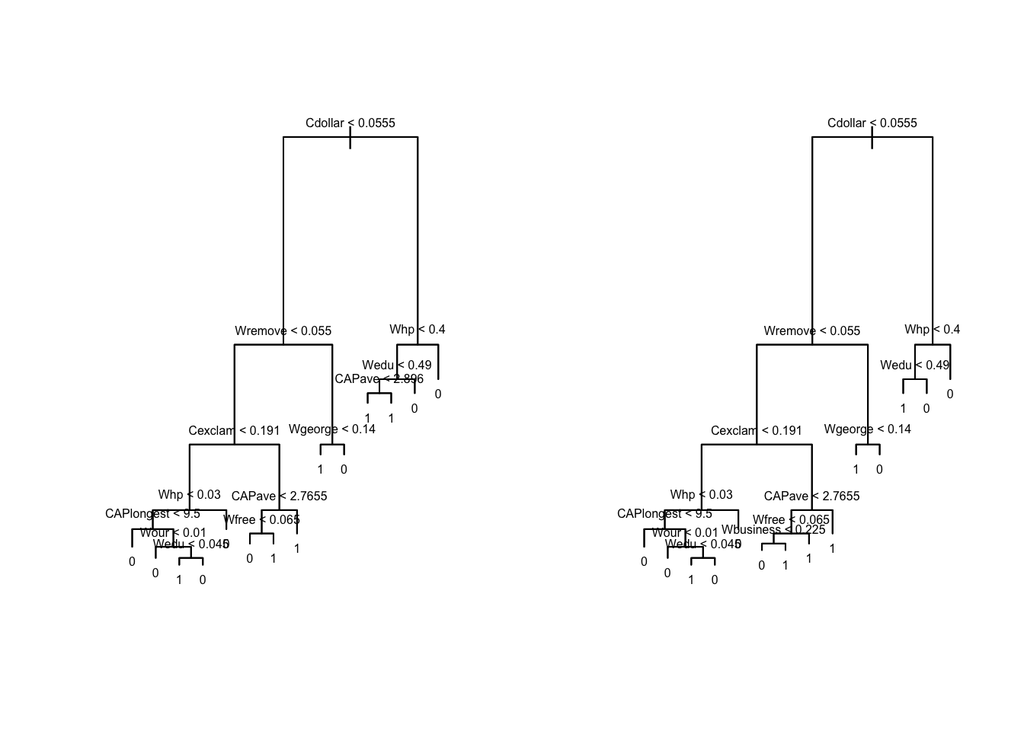

```r
bestsize=14;
spam.tr1=prune.tree(spam.tr, best=bestsize);
spam.tr2=prune.misclass(spam.tr, best=bestsize); # should be the same as:
#spam.tr2=prune.tree(spam.tr, method="misclass", best=bestsize);

par(mfrow=c(1,2));
plot(spam.tr1);
text(spam.tr1, cex=0.5);
plot(spam.tr2);
text(spam.tr2, cex=0.5);
```

It’s important to note that in the left tree (which has been trimmed based on deviance), there is a particular node where the two leaf nodes have the same prediction. Such a branch might be pruned if we use the mis-classification rate as a criterion for tree pruning, as the mis-classification rate would remain the same if we were to cut that branch. However, it’s worth mentioning that such a branch could still contribute significantly to reducing the deviance.

## Prediction

Check how to obtain predictions using the fitted classification tree.

```r
??predict.tree
```

```r
train.pred1 = predict(spam.tr1, spam[-test.id,], type="class")
table(train.pred1, spam$Y[-test.id])


train.pred2 = predict(spam.tr2, spam[-test.id,], type="class")
table(train.pred2, spam$Y[-test.id])

test.pred1 = predict(spam.tr1, spam[test.id,], type="class")
table(test.pred1, spam$Y[test.id])

test.pred2 = predict(spam.tr2, spam[test.id,], type="class")
table(test.pred2, spam$Y[test.id])
```

[output not shown]

[output not shown]